# Shiny-seq: Making Bioinformatics Accessible

02/05/2020

## Single Cell RNA Sequencing (scRNA-seq)

The most basic question of molecular biology: Which cells express my gene of interest?

Single Cell RNA Sequencing (scRNA-seq) can answer this question in ways that was previously impossible  
- Uses microfluidics to capture a single cell with a uniquely tagged bead  
- Quantifies tens of thousands of genes in thousands of cells simultaneously

However, scRNA-seq analysis is out of reach for the majority of biologists because it requires advanced computer programming and statistics to analyze including:  
- SQL, R, python, and bash  
- linear regression, logirithmic scaling, Principal Component Analysis  
- Nearest-Neighbor clustering, dimension reduction (tSNE, UMAP)

## The Shiny-seq App: Input Data

Shiny-seq allows for someone with no experience in computer science to query which cells express their gene of interest. It loads a scRNA-seq dataset (Saunders et. al, 2018) that has been preprocessed with the R package [Seurat](https://satijalab.org/seurat/):

```r
scRNAseqData <- readRDS("GP_downsample.RDS")
scRNAseqData
```

```
## An object of class Seurat
## 44271 features across 2592 samples within 2 assays
## Active assay: SCT (20785 features, 3000 variable features)
##  1 other assay present: RNA
##  3 dimensional reductions calculated: pca, umap, tsne
```

It then runs a query for a user entered gene and returns expression plots displaying which cells express the gene of interest.

## The Shiny-seq App Output

Shiny-seq will output two plots that allow the end user to detirmine which cells express the gene of interest.

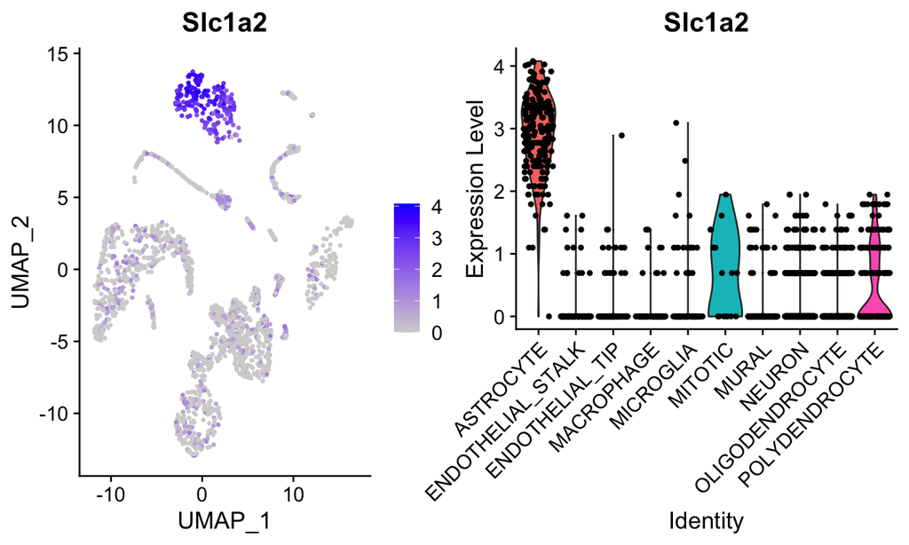

```r
f <- FeaturePlot(scRNAseqData, features = "Slc1a2")
v <- VlnPlot(scRNAseqData, features = "Slc1a2", group.by = "class") + theme(legend.position = "none")
grid.arrange(f, v, ncol = 2)
```

## Where to find Shiny-seq

The app can be found at: https://wtoddfarmer.shinyapps.io/Shiny-seq/

The source can be found at: https://github.com/wtoddfarmer/shiny-seq